# Lab. 2 ARMA models

Análisis y Predicción de Series Temporales, 3º B IMAT

2024-09-013

# Lab. 2 ARMA models

# Preliminaries

## Load libraries

If you get an error go to the packages panel, click install and type the name of the library (you only need to do this once).

```r
library(fpp2)
library(tidyverse)
library(readxl)
library(lmtest) #contains coeftest function
```

To install the next one you need to:

- Download the file `MLTools_0.0.31.tar.gz` from Moodle ([R libraries section](https://sifo.comillas.edu/course/view.php?id=46499#section-9&module-3149241)).
- Go to the packages panel,
- Click *Install*
- Under *Install from* select *PAckage Archive File*
- Navigate to the folder where you downloaded the package and select it.
- Click install and wait for the setup to finish.

```r
library(MLTools)
```

## Set the working directory

```r
setwd(dirname(rstudioapi::getActiveDocumentContext()$path))
```

# Reading time series data and EDA

## Load dataset

```r
fdata <- read_excel("ARMA_series.xls")
```

Visualize the first rows:

```r
head(fdata)
```

```
## # A tibble: 6 × 6
##        y1     y2      y3    y4      y5     y6
##     <dbl>  <dbl>   <dbl> <dbl>   <dbl>  <dbl>
## 1  0       0      0       0     0       0
## 2  0.153  -0.717 -1.71    0     1.67   -0.492
## 3 -0.407  -0.389  0.0653  1.45 -0.257   1.60
## 4  0.0383  0.393  0.509   1.85 -0.0995 -0.525
## 5 -0.0557 -1.40  -0.237   4.16 -1.09    0.320
## 6  0.0899  0.809 -0.630   2.95  3.49   -0.622
```

## Convert it to a (multi)time series object

In this case:

- We assume that there are no time gaps
- There is no temporal information in the data, so we use the natural numbers as index. Thi is the default in `ts` if no additional arguments are used.

```r
fdata_ts <- ts(fdata)

head(fdata_ts)
```

```
## Time Series:
## Start = 1
## End = 6
## Frequency = 1
##            y1         y2          y3       y4          y5         y6
## 1  0.00000000  0.0000000  0.00000000 0.000000  0.00000000  0.0000000
## 2  0.15308507 -0.7165780 -1.71442720 0.000000  1.67224070 -0.4915498
## 3 -0.40741828 -0.3887689  0.06525109 1.450110 -0.25668180  1.6003533
## 4  0.03831497  0.3933029  0.50867057 1.845359 -0.09947878 -0.5246700
## 5 -0.05568611 -1.3998697 -0.23749804 4.164812 -1.09044400  0.3197939
## 6  0.08986429  0.8092756 -0.63004594 2.951456  3.49057750 -0.6224836
```

We use the column index to select a time series

```r
y <- fdata_ts[ ,2]
```

# Identification and fitting process

## ACF and PACF plots of the time series

We use them to identify significant lags and order

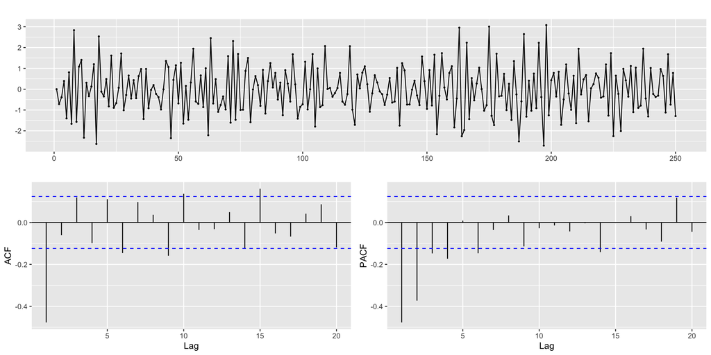

```r
ggtsdisplay(y, lag.max = 20)
```

## ARMA model selection and fit

Now we propose a structure of the model by selecting the values of p and q

```r
p <- 1
q <- 1

# We fit the model with estimated order

arima.fit <- Arima(y, order=c(p, 0, q), include.mean = TRUE)

# And we use `summary` to display the training errors and estimated coefficients.

summary(arima.fit)
```

```
## Series: y
## ARIMA(1,0,1) with non-zero mean
##
## Coefficients:
##           ar1      ma1     mean
##       -0.0209  -0.7476  -0.0077
## s.e.   0.0895   0.0648   0.0146
##
## sigma^2 = 0.8666:  log likelihood = -335.76
## AIC=679.51   AICc=679.68   BIC=693.6
##
## Training set error measures:
##                        ME      RMSE       MAE MPE MAPE      MASE         ACF1
## Training set -0.006359145 0.9253249 0.7463957 Inf  Inf 0.4566577 -0.001999382
```

# Model diagnosis

The next function explores the statistical significance of the estimated coefficients

```r
coeftest(arima.fit)
```

```
##
## z test of coefficients:
##
##             Estimate Std. Error  z value Pr(>|z|)
## ar1       -0.0209400  0.0894843  -0.2340   0.8150
## ma1       -0.7475557  0.0647692 -11.5418   <2e-16 ***
## intercept -0.0076721  0.0146470  -0.5238   0.6004
## ---
## Signif. codes:  0 '***' 0.001 '**' 0.01 '*' 0.05 '.' 0.1 ' ' 1
```

We use the information to update the ARMA structure if needed. Using autoplot with the fitted model results in a *root plot* to check stationarity and invertibility

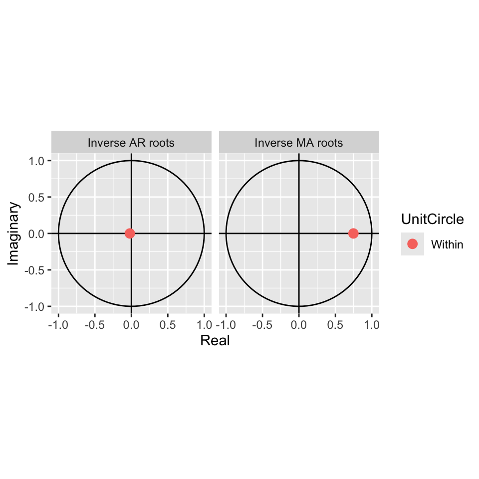

```r
autoplot(arima.fit)
```

## Check of the residuals

The residual plots can be used to check the hypothesis of the ARMA model:

- The time plot of the residuals should look like white noise (no patterns)
- The histogram and density curve help assess the normality.
- The ACF and PACF should show no significant values (up to 5%), in particular in the first lags.

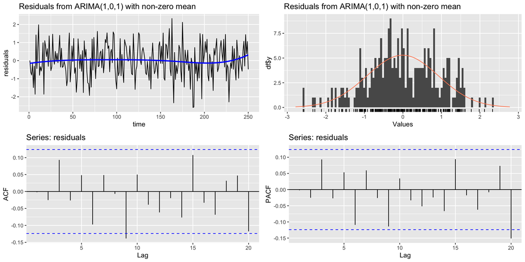

```
##
##  Ljung-Box test
##
## data:  Residuals from ARIMA(1,0,1) with non-zero mean
## Q* = 24.309, df = 17, p-value = 0.1113
##
## Model df: 3.   Total lags used: 20
```

```r
CheckResiduals.ICAI(arima.fit, bins = 100, lag=20)
```

Remember: you should also check the p-value of the Ljung-Box test in the output of `CheckResiduals`.

An alternative residual plot is obtained with

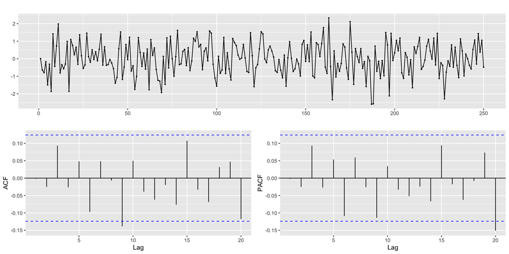

```r
ggtsdisplay(residuals(arima.fit), lag.max = 20)
```

Keep in mind that if the residuals are not white noise, you should change the order of the ARMA model.

# Fitted time series and forecasting with the fitted model

We begin by reconstructing the series with the model. That is, we obtain the fitted value at $t$
$$\hat{y}_{t|t-1}$$
for all $t$ in the training data.

The following plot compares the original time series with the reconstructed (fitted) values:

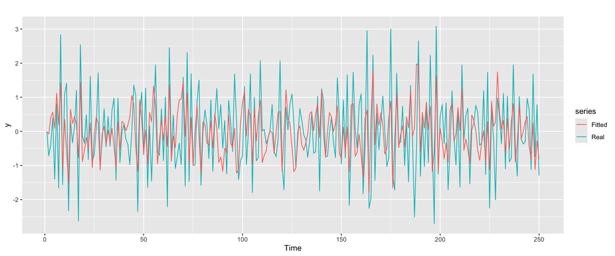

```r
autoplot(y, series = "Real") +
  forecast::autolayer(arima.fit$fitted, series = "Fitted")
```

Now, for a **true forecast of future values** we use the `horizon` parameter `h`:

```r
y_est <- forecast::forecast(arima.fit, h=5)
```

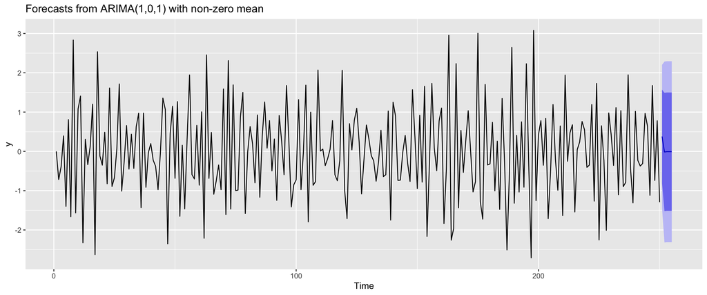

```r
autoplot(y_est)
```

# ARMA time series simulation

The series we have been using are synthetic time series, obtained as in the example below:

```r
set.seed(2024)
sim_ts <- arima.sim(n = 250,
                 list(ar = c(0.8897, -0.4858), ma = c(-0.2279, 0.2488)),
                 sd = sqrt(0.1796))
```

See [Hyndman fpp3, sections 9.3 and 9.4](https://otexts.com/fpp3/AR.html) for the conditions that the model coefficients should verify.